# MRMCaov for R User Guide

Package Version 0.3.1

Brian J Smith

Department of Biostatistics, University of Iowa  
brian-j-smith@uiowa.edu

Stephen L Hillis

Departments of Radiology and Biostatistics, University of Iowa  
steve-hillis@uiowa.edu

2025-09-26

# 1 Getting Started

**MRMCaov** is an R package for statistical comparison of diagnostic tests - such as those based on medical imaging - for which ratings have been obtained from multiple readers and on multiple cases. Features of the package include the following.

- Statistical comparisons of diagnostic tests with respect to reader performance metrics
- Comparisons based on the ANOVA model of Obuchowski-Rockette and the unified framework of Hillis
- Reader performance metrics for area under receiver operating characteristic curves (ROC AUCs), partial AUCs, expected utility of ROC curves, likelihood ratio of positive or negative tests, sensitivity, specificity, and user-defined metrics
- Parametric and nonparametric estimation and plotting of ROC curves
- Support for factorial, nested, and partially paired study designs
- Inference for random or fixed readers and cases
- Conversion of Obuchowski-Rockette to Roe, Metz & Hillis model parameters and vice versa
- DeLong, jackknife, and unbiased covariance estimation
- Compatibility with Microsoft Windows, MacOS, and Linux

## 1.1 Documentation: [User Guide](https://brian-j-smith.github.io/MRMCaov/using.html)

## 1.2 Installation

Enter the following at the R console to install the package.

```r
install.packages("MRMCaov")
```

## 1.3 Citing the Software

```r
## Text format
citation("MRMCaov")
```

[output not shown]

```r
## Bibtex format
toBibtex(citation("MRMCaov"))
```

```
@Manual{MRMCaov-package,
  author = {Brian J Smith and Stephen L Hillis and Lorenzo L Pesce},
  title = {{MCMCaov}: Multi-Reader Multi-Case Analysis of Variance},
  year = {2025},
  note = {R package version 0.3.1},
  url = {https://cran.r-project.org/package=MRMCaov},
}

@InProceedings{MRMCaov-SPIE2020,
  author = {Brian J. Smith and Stephen L. Hillis},
  title = {Multi-reader multi-case analysis of variance software for diagnostic performance comparison of imaging modalities},
  booktitle = {Proceedings of SPIE 11316, Medical Imaging 2020: Image Perception, Observer Performance, and Technology Assessment},
  editor = {Frank Samuelson and Sian Taylor-Phillips},
  month = {16 March},
  year = {2020},
  pages = {113160K},
  doi = {10.1117/12.2549075},
  url = {https://pubmed.ncbi.nlm.nih.gov/32351258},
}
```

# 2 Introduction

A common study design for comparing the diagnostic performance of imaging modalities, or diagnostic tests, is to obtain modality-specific ratings from multiple readers of multiple cases (MRMC) whose true statuses are known. In such a design, receiver operating characteristic (ROC) indices, such as area under the ROC curve (ROC AUC), can be used to quantify correspondence between reader ratings and case status. Indices can then be compared statistically to determine if there are differences between modalities. However, special statistical methods are needed when readers or cases represent a random sample from a larger population of interest and there is overlap between modalities, readers, and/or cases. An ANOVA model designed for these characteristics of MRMC studies was initially proposed by Dorfman et al. (Dorfman, Berbaum, and Metz 1992) and Obuchowski and Rockette (Obuchowski and Rockette 1995) and later unified and improved by Hillis and colleagues (Hillis et al. 2005; Hillis 2007, 2018; Hillis, Berbaum, and Metz 2008). Their models are implemented in the **MRMCaov** R package (Smith, Hillis, and Pesce 2022).

# 3 Obuchowski and Rockette Model

**MRMCaov** implements multi-reader multi-case analysis based on the Obuchowski and Rockette (1995) analysis of variance (ANOVA) model
$$\hat{\theta}_{ij} = \mu + \tau_i + R_j + (\tau R)_{ij} + \epsilon_{ij},$$
where $i = 1,\ldots,t$ and $j = 1,\ldots,r$ index diagnostic tests and readers; $\hat{\theta}_{ij}$ is a reader performance metric, such as ROC AUC, estimated over multiple cases; $\mu$ an overall study mean; $\tau_i$ a fixed test effect; $R_j$ a random reader effect; $(\tau R)_{ij}$ a random test $\times$ reader interaction effect; and $\epsilon_{ij}$ a random error term. The random terms $R_j$, $(\tau R)_{ij}$, and $\epsilon_{ij}$ are assumed to be mutually independent and normally distributed with 0 means and variances $\sigma^2_R$, $\sigma^2_{TR}$, and $\sigma^2_\epsilon$.

In the Obuchowski-Rockette ANOVA model, $\sigma^2_\epsilon$ can be interpreted as the performance metric variance for a single fixed reader and test; and $\text{Cov}_1$, $\text{Cov}_2$, and $\text{Cov}_3$ as the performance metric covariances for the same reader of two different tests, two different readers of the same test, and two different readers of two different tests. These error variance and covariance parameters are estimated in the package by averaging the reader and test-specific estimates computed using jackknifing (Efron 1982) or, for empirical ROC AUC, an unbiased estimator (Gallas, Pennello, and Meyers 2007) or the method of DeLong (DeLong, DeLong, and Clarke-Pearson 1988).

# 4 VanDyke Example

Use of the **MRMCaov** package is illustrated with data from a study comparing the relative performance of cinematic presentation of MRI (CINE MRI) to single spin-echo magnetic resonance imaging (SE MRI) for the detection of thoracic aortic dissection (VanDyke et al. 1993). In the study, 45 patients with aortic dissection and 69 without dissection were imaged with both modalities. Based on the images, five radiologists rated patients disease statuses as 1 = definitely no aortic dissection, 2 = probably no aortic dissection, 3 = unsure about aortic dissection, 4 = probably aortic dissection, or 5 = definitely aortic dissection. Interest lies in estimating ROC curves for each combination of reader and modality and in comparing modalities with respect to summary statistics from the curves. The study data are included in the package as a data frame named `VanDyke`.

```r
## Load MRMCaov library and VanDyke dataset
library(MRMCaov)
data(VanDyke, package = "MRMCaov")
```

[output not shown]

The study employed a factorial design in which each of the five radiologists read and rated both the CINE and SE MRI images from all 114 cases. The original study variables in the `VanDyke` data frame are summarized below along with two additional `case2` and `case3` variables that represent hypothetical study designs in which cases are nested within readers (`reader`) and within imaging modalities (`treatment`), respectively.

| Variable | Description |
| --- | --- |
| `reader` | unique identifiers for the five radiologists |
| `treatment` | identifiers for the imaging modality (1 = CINE MRI, 2 = SE MRI) |
| `case` | identifiers for the 114 cases |
| `truth` | indicator for thoracic aortic dissection (1 = performed, 0 = not performed) |
| `rating` | five-point ratings given to case images by the readers |
| `case2` | example identifiers representing nesting of cases within readers |
| `case3` | example identifiers representing nesting of cases within treatments |

Data from other studies may be analyzed with the package and should follow the format of `VanDyke` with columns for reader, treatment, and case identifiers as well as true event statuses and reader ratings. The variable names, however, may be different.

# 5 Multi-Reader Multi-Case Analysis

A multi-reader multi-case (MRMC) analysis, as the name suggests, involves multiple readers of multiple cases to compare reader performance metrics across two or more diagnostic tests. An MRMC analysis can be performed with a call to the `mrmc()` function to specify a reader performance metric, study variables and observations, and covariance estimation method.

> **MRMC Function**

> `mrmc(response, test, reader, case, data, cov = jackknife)`

> *Description*

> Returns an `mrmc` class object of data that can be used to estimate and compare reader performance metrics in a multi-reader multi-case statistical analysis.

> *Arguments*
> - `response`: object defining true case statuses, corresponding reader ratings, and a reader performance metric to compute on them.
> - `test`, `reader`, `case`: variables containing the test, reader, and case identifiers for the `response` observations.
> - `data`: data frame containing the response and identifier variables.
> - `cov`: function `jackknife`, `unbiased`, or `DeLong` to estimate reader performance metric covariances.

The response variable in the `mrmc()` specification is defined with one of the performance metrics described in the following sections. Results from `mrmc()` can be displayed with `print()` and passed to `summary()` for statistical comparisons of the diagnostic tests. The summary call produces ANOVA results from a global test of equality of ROC AUC means across all tests and statistical tests of pairwise differences, along with confidence intervals for the differences and intervals for individual tests.

> **MRMC Summary Function**

> `summary(object, conf.level = 0.95)`

> *Description*

> Returns a `summary.mrmc` class object of statistical results from a multi-reader multi-case analysis.

> *Arguments*
> - `object`: results from `mrmc()`.
> - `conf.level`: confidence level for confidence intervals.

## 5.1 Performance Metrics

### 5.1.1 Area Under the ROC Curve

Area under the ROC curve is a measure of concordance between numeric reader ratings and true binary case statuses. It provides an estimate of the probability that a randomly selected positive case will have a higher rating than a negative case. ROC AUC values range from 0 to 1, with 0.5 representing no concordance and 1 perfect concordance. AUC can be computed with the functions described below for binormal, binormal likelihood-ratio, and empirical ROC curves. Empirical curves are also referred to as trapezoidal. The functions also support calculation of partial AUC over a range of sensitivities or specificities.

> **ROC AUC Functions**

> `binormal_auc(truth, rating, partial = FALSE, min = 0, max = 1, normalize = FALSE)`  
> `binormalLR_auc(truth, rating, partial = FALSE, min = 0, max = 1, normalize = FALSE)`  
> `empirical_auc(truth, rating, partial = FALSE, min = 0, max = 1, normalize = FALSE)`  
> `trapezoidal_auc(truth, rating, partial = FALSE, min = 0, max = 1, normalize = FALSE)`

> *Description*

> Returns computed area under the receiver operating character curve estimated with a binormal model (`binormal_auc`), binormal likelihood-ratio model (`binormalLR_auc`), or empirically (`empirical_auc` or `trapezoidal_auc`).

> *Arguments*
> - `truth`: vector of true binary case statuses, with positive status taken to be the highest level.
> - `rating`: numeric vector of case ratings.
> - `partial`: character string `"sensitivity"` or `"specificity"` for calculation of partial AUC, or `FALSE` for full AUC. Partial matching of the character strings is allowed. A value of `"specificity"` results in area under the ROC curve between the given `min` and `max` specificity values, whereas `"sensitivity"` results in area to the right of the curve between the given sensitivity values.
> - `min`, `max`: minimum and maximum sensitivity or specificity values over which to calculate partial AUC.
> - `normalize`: logical indicating whether partial AUC is divided by the interval width (`max - min`) over which it is calculated.

In the example below, `mrmc()` is called to compare CINE MRI and SE MRI treatments in an MRMC analysis of areas under binormal ROC curves computed for the readers of cases in the VanDyke study.

```r
## Compare ROC AUC treatment means for the VanDyke example
est <- mrmc(
  binormal_auc(truth, rating), treatment, reader, case, data = VanDyke
)
```

The `print()` function can be applied to `mrmc()` output to display information about the reader performance metrics, including the

- value of variable `truth` (1) defining positive case status,
- estimated performance metric values (`data$binormal_auc`) for each test (`$treatment`) and reader (`$reader`),
- number of cases read at each level of the factors (`N`), and
- error variance $\sigma^2_\epsilon$ and covariances $\text{Cov}_1$, $\text{Cov}_2$, and $\text{Cov}_3$.

**Show MRMC Performance Metrics**

```r
print(est)
```

```
## Call:
## mrmc(response = binormal_auc(truth, rating), test = treatment,
##     reader = reader, case = case, data = VanDyke)
##
## Positive truth status: 1
##
## Response metric data:
##
## # A tibble: 10 × 2
##        N data$binormal_auc $treatment $reader
##    <dbl>             <dbl> <fct>      <fct>
##  1   114             0.933 1          1
##  2   114             0.890 1          2
##  3   114             0.929 1          3
##  4   114             0.970 1          4
##  5   114             0.833 1          5
##  6   114             0.951 2          1
##  7   114             0.935 2          2
##  8   114             0.928 2          3
##  9   114             1     2          4
## 10   114             0.945 2          5
##
## ANOVA Table:
##
##                  Df    Sum Sq   Mean Sq
## treatment         1 0.0041142 0.0041142
## reader            4 0.0104325 0.0026081
## treatment:reader  4 0.0037916 0.0009479
##
##
## Obuchowski-Rockette error variance and covariance estimates:
##
##           Estimate Correlation
## Error 0.0010790500          NA
## Cov1  0.0003125013   0.2896078
## Cov2  0.0003115986   0.2887713
## Cov3  0.0001937688   0.1795735
```

MRMC statistical tests are performed with a call to `summary()`. Results include a test of the global null hypothesis that performances are equal across all diagnostic tests, tests of their pairwise mean differences, and estimated mean performances for each one.

**Show MRMC Test Results**

```r
summary(est)
```

```
## Multi-Reader Multi-Case Analysis of Variance
## Data: VanDyke
## Factor types: Random Readers and Random Cases
## Covariance method: jackknife
##
## Experimental design: factorial
##
## Obuchowski-Rockette variance component and covariance estimates:
##
##                      Estimate Correlation
## reader           0.0007113799          NA
## treatment:reader 0.0002991713          NA
## Error            0.0010790500          NA
## Cov1             0.0003125013   0.2896078
## Cov2             0.0003115986   0.2887713
## Cov3             0.0001937688   0.1795735
##
##
## ANOVA global test of equal treatment binormal_auc:
##         MS(T)      MS(T:R)         Cov2         Cov3 Denominator        F df1
## 1 0.004114188 0.0009478901 0.0003115986 0.0001937688 0.001537039 2.676697   1
##        df2   p-value
## 1 10.51753 0.1313668
##
##
## 95% CIs and tests for treatment binormal_auc pairwise differences:
##   Comparison    Estimate     StdErr       df    CI.Lower    CI.Upper         t
## 1      1 - 2 -0.04056692 0.02479548 10.51753 -0.09544840  0.01431455 -1.636061
##     p-value
## 1 0.1313668
##
##
## 95% treatment binormal_auc CIs (each analysis based only on data for the
## specified treatment):
##    Estimate        MS(R)         Cov2     StdErr       df  CI.Lower  CI.Upper
## 1 0.9109867 0.0027417526 0.0004612201 0.03177374 13.55866 0.8426301 0.9793433
## 2 0.9515536 0.0008142524 0.0001619772 0.01802298 15.91432 0.9133299 0.9897774
```

ROC curves estimated by `mrmc()` can be displayed with `plot()` and their parameters extracted with `parameters()`.

**Show MRMC ROC Curves**

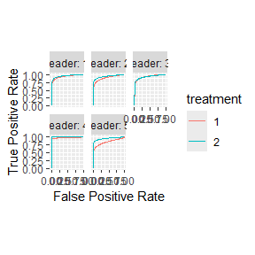

```r
plot(est)
```

**Show MRMC ROC Curve Parameters**

```r
print(parameters(est))
```

```
## # A tibble: 10 × 3
##    Group$reader $treatment      a     b
##    <fct>        <fct>       <dbl> <dbl>
##  1 1            1            1.70 0.537
##  2 2            1            1.40 0.561
##  3 3            1            1.74 0.635
##  4 4            1            1.93 0.202
##  5 5            1            1.06 0.464
##  6 1            2            1.85 0.503
##  7 2            2            1.66 0.447
##  8 3            2            1.62 0.488
##  9 4            2          Inf    1
## 10 5            2            1.73 0.422
```

### 5.1.2 ROC Curve Expected Utility

As an alternative to AUC as a summary of ROC curves, Abbey et al. (2013) propose an expected utility metric defined as
$$\text{EU} = \max_\text{FPR}(\text{TPR}(\text{FPR}) - \beta \times
\text{FPR}),$$
where $\text{TPR}(\text{FPR})$ are true positive rates on the ROC curve, and FPR are false positive rates ranging from 0 to 1.

> **ROC Curve Expected Utility Functions**

> `binormal_eu(truth, rating, slope = 1)`  
> `binormalLR_eu(truth, rating, slope = 1)`  
> `empirical_eu(truth, rating, slope = 1)`  
> `trapezoidal_eu(truth, rating, slope = 1)`

> *Description*

> Returns expected utility of an ROC curve.

> *Arguments*
> - `truth`: vector of true binary case statuses, with positive status taken to be the highest level.
> - `rating`: numeric vector of case ratings.
> - `slope`: numeric slope ($\beta$) at which to compute expected utility.

### 5.1.3 ROC Curve Sensitivity and Specificity

Functions are provided to extract sensitivity from an ROC curve for a given specificity and vice versa.

> **ROC Curve Sensitivity and Specificity Functions**

> `binormal_sens(truth, rating, spec)`  
> `binormal_spec(truth, rating, sens)`  
> `binormalLR_sens(truth, rating, spec)`  
> `binormalLR_spec(truth, rating, sens)`  
> `empirical_sens(truth, rating, spec)`  
> `empirical_spec(truth, rating, sens)`  
> `trapezoidal_sens(truth, rating, spec)`  
> `trapezoidal_spec(truth, rating, sens)`

> *Description*

> Returns the sensitivity/specificity from an ROC curve at a specified specificity/sensitivity.

> *Arguments*
> - `truth`: vector of true binary case statuses, with positive status taken to be the highest level.
> - `rating`: numeric vector of case ratings.
> - `spec`, `sens`: specificity/sensitivity on the ROC curve at which to return sensitivity/specificity.

### 5.1.4 Binary Metrics

Metrics for binary reader ratings are also available.

> **Sensitivity and Specificity Functions**

> `binary_sens(truth, rating)`  
> `binary_spec(truth, rating)`

> *Description*

> Returns the sensitivity or specificity.

> *Arguments*
> - `truth`: vector of true binary case statuses, with positive status taken to be the highest level.
> - `rating`: factor or numeric vector of 0-1 binary ratings.

```r
## Compare sensitivity for binary classification
VanDyke$binary_rating <- VanDyke$rating >= 3
est <- mrmc(
  binary_sens(truth, binary_rating), treatment, reader, case, data = VanDyke
)
```

**Show MRMC Performance Metrics**

```r
print(est)
```

```
## Call:
## mrmc(response = binary_sens(truth, binary_rating), test = treatment,
##     reader = reader, case = case, data = VanDyke)
##
## Positive truth status: 1
##
## Response metric data:
##
## # A tibble: 10 × 2
##        N data$binary_sens $treatment $reader
##    <dbl>            <dbl> <fct>      <fct>
##  1    45            0.889 1          1
##  2    45            0.778 1          2
##  3    45            0.822 1          3
##  4    45            0.933 1          4
##  5    45            0.689 1          5
##  6    45            0.978 2          1
##  7    45            0.822 2          2
##  8    45            0.911 2          3
##  9    45            1     2          4
## 10    45            0.889 2          5
##
## ANOVA Table:
##
##                  Df   Sum Sq   Mean Sq
## treatment         1 0.023901 0.0239012
## reader            4 0.049679 0.0124198
## treatment:reader  4 0.007210 0.0018025
##
##
## Obuchowski-Rockette error variance and covariance estimates:
##
##           Estimate Correlation
## Error 0.0023681257          NA
## Cov1  0.0009943883   0.4199052
## Cov2  0.0010145903   0.4284360
## Cov3  0.0006604938   0.2789100
```

**Show MRMC Test Results**

```r
summary(est)
```

```
## Multi-Reader Multi-Case Analysis of Variance
## Data: VanDyke
## Factor types: Random Readers and Random Cases
## Covariance method: jackknife
##
## Experimental design: factorial
##
## Obuchowski-Rockette variance component and covariance estimates:
##
##                      Estimate Correlation
## reader           0.0049747475          NA
## treatment:reader 0.0007828283          NA
## Error            0.0023681257          NA
## Cov1             0.0009943883   0.4199052
## Cov2             0.0010145903   0.4284360
## Cov3             0.0006604938   0.2789100
##
##
## ANOVA global test of equal treatment binary_sens:
##        MS(T)     MS(T:R)       Cov2         Cov3 Denominator        F df1
## 1 0.02390123 0.001802469 0.00101459 0.0006604938 0.003572952 6.689493   1
##        df2    p-value
## 1 15.71732 0.02008822
##
##
## 95% CIs and tests for treatment binary_sens pairwise differences:
##   Comparison    Estimate     StdErr       df   CI.Lower   CI.Upper         t
## 1      1 - 2 -0.09777778 0.03780451 15.71732 -0.1780371 -0.0175185 -2.586405
##      p-value
## 1 0.02008822
##
##
## 95% treatment binary_sens CIs (each analysis based only on data for the
## specified treatment):
##    Estimate       MS(R)        Cov2     StdErr        df  CI.Lower  CI.Upper
## 1 0.8222222 0.009135802 0.001646465 0.05893747 14.456811 0.6961876 0.9482568
## 2 0.9200000 0.005086420 0.000382716 0.03741657  7.575855 0.8328691 1.0000000
```

## 5.2 Covariance Estimation Methods

Special statistical methods are needed in MRMC analyses to estimate covariances between performance metrics from different readers and tests when cases are treated as a random sample and are rated by more than one reader or evaluated with more than one test. For this estimation, the package provides the DeLong method (DeLong, DeLong, and Clarke-Pearson 1988), jackknifing (Efron 1982), and an unbiased method (Gallas, Pennello, and Meyers 2007). The applicability of each depends on the study design as well as the performance metric being analyzed. DeLong is appropriate for a balanced factorial design and empirical ROC AUC, jackknifing for any design and metric, and unbiased for any design and empirical ROC AUC.

| Covariance Method | Study Design | Metric | Function |
| --- | --- | --- | --- |
| DeLong | Factorial | Empirical ROC AUC | `DeLong()` |
| Jackknife | Any | Any | `jackknife()` |
| Unbiased | Any | Empirical ROC AUC | `unbiased()` |

Jackknifing is the default covariance method for `mrmc()`. Others can be specified with its `cov` argument.

```r
## DeLong method
est <- mrmc(
  empirical_auc(truth, rating), treatment, reader, case, data = VanDyke,
  cov = DeLong
)
```

**Show MRMC Test Results**

```r
summary(est)
```

```
## Multi-Reader Multi-Case Analysis of Variance
## Data: VanDyke
## Factor types: Random Readers and Random Cases
## Covariance method: DeLong
##
## Experimental design: factorial
##
## Obuchowski-Rockette variance component and covariance estimates:
##
##                      Estimate Correlation
## reader           0.0015364254          NA
## treatment:reader 0.0002045840          NA
## Error            0.0007921325          NA
## Cov1             0.0003420090   0.4317573
## Cov2             0.0003395265   0.4286234
## Cov3             0.0002358497   0.2977402
##
##
## ANOVA global test of equal treatment empirical_auc:
##         MS(T)      MS(T:R)         Cov2         Cov3 Denominator        F df1
## 1 0.004796171 0.0005510306 0.0003395265 0.0002358497 0.001069415 4.484854   1
##        df2    p-value
## 1 15.06611 0.05123303
##
##
## 95% CIs and tests for treatment empirical_auc pairwise differences:
##   Comparison    Estimate    StdErr       df      CI.Lower      CI.Upper
## 1      1 - 2 -0.04380032 0.0206825 15.06611 -0.0878671960  0.0002665519
##           t    p-value
## 1 -2.117747 0.05123303
##
##
## 95% treatment empirical_auc CIs (each analysis based only on data for the
## specified treatment):
##    Estimate       MS(R)         Cov2     StdErr       df  CI.Lower  CI.Upper
## 1 0.8970370 0.003082629 0.0004775239 0.03307642 12.59597 0.8253461 0.9687280
## 2 0.9408374 0.001304602 0.0002015292 0.02150464 12.56530 0.8942155 0.9874592
```

```r
## Unbiased method
est <- mrmc(
  empirical_auc(truth, rating), treatment, reader, case, data = VanDyke,
  cov = unbiased
)
```

**Show MRMC Test Results**

```r
summary(est)
```

```
## Multi-Reader Multi-Case Analysis of Variance
## Data: VanDyke
## Factor types: Random Readers and Random Cases
## Covariance method: unbiased
##
## Experimental design: factorial
##
## Obuchowski-Rockette variance component and covariance estimates:
##
##                      Estimate Correlation
## reader           0.0015365290          NA
## treatment:reader 0.0002077588          NA
## Error            0.0007883925          NA
## Cov1             0.0003416706   0.4333762
## Cov2             0.0003390650   0.4300713
## Cov3             0.0002356148   0.2988547
##
##
## ANOVA global test of equal treatment empirical_auc:
##         MS(T)      MS(T:R)        Cov2         Cov3 Denominator        F df1
## 1 0.004796171 0.0005510306 0.000339065 0.0002356148 0.001068281 4.489614   1
##        df2   p-value
## 1 15.03418 0.0511618
##
##
## 95% CIs and tests for treatment empirical_auc pairwise differences:
##   Comparison    Estimate     StdErr       df      CI.Lower      CI.Upper
## 1      1 - 2 -0.04380032 0.02067154 15.03418 -0.0878519409  0.0002512968
##           t   p-value
## 1 -2.118871 0.0511618
##
##
## 95% treatment empirical_auc CIs (each analysis based only on data for the
## specified treatment):
##    Estimate       MS(R)         Cov2    StdErr       df  CI.Lower  CI.Upper
## 1 0.8970370 0.003082629 0.0004771788 0.0330712 12.58802 0.8253526 0.9687214
## 2 0.9408374 0.001304602 0.0002009512 0.0214912 12.53391 0.8942323 0.9874424
```

## 5.3 Fixed Factors

By default, readers and cases are treated as random effects by `mrmc()`. Random effects are the appropriate designations when inference is intended for the larger population from which study readers and cases are considered to be a random sample. Either, but not both, can be specified as fixed effects with the `fixed()` function in applications where study readers or cases make up the entire group to which inference is intended. When readers are designated as fixed, `mrmc()` test results additionally include reader-specific pairwise comparisons of the diagnostic tests as well as mean estimates of the performance metric for each reader-test combination.

```r
## Fixed readers
est <- mrmc(
  empirical_auc(truth, rating), treatment, fixed(reader), case, data = VanDyke
)
```

**Show MRMC Test Results**

```r
summary(est)
```

```
## Multi-Reader Multi-Case Analysis of Variance
## Data: VanDyke
## Factor types: Fixed Readers and Random Cases
## Covariance method: jackknife
##
## Experimental design: factorial
##
## Obuchowski-Rockette variance component and covariance estimates:
##
##                      Estimate Correlation
## reader           0.0015349993          NA
## treatment:reader 0.0002004025          NA
## Error            0.0008022883          NA
## Cov1             0.0003466137   0.4320314
## Cov2             0.0003440748   0.4288668
## Cov3             0.0002390284   0.2979333
##
##
## ANOVA global test of equal treatment empirical_auc:
##         MS(T)         Cov1         Cov2         Cov3  Denominator       X2 df
## 1 0.004796171 0.0003466137 0.0003440748 0.0002390284 0.0008758604 5.475953  1
##      p-value
## 1 0.01927984
##
##
## 95% CIs and tests for treatment empirical_auc pairwise differences:
##   Comparison    Estimate     StdErr    CI.Lower    CI.Upper         z
## 1      1 - 2 -0.04380032 0.01871748 -0.08048591 -0.00711473 -2.340075
##      p-value
## 1 0.01927984
##
##
## 95% treatment empirical_auc CIs (each analysis based only on data for the
## specified treatment):
##    Estimate   Var(Error)         Cov2     StdErr  CI.Lower  CI.Upper
## 1 0.8970370 0.0010141028 0.0004839618 0.02428971 0.8494301 0.9446440
## 2 0.9408374 0.0005904738 0.0002041879 0.01677632 0.9079564 0.9737183
##
##
## Reader-specific 95% CIs and tests for empirical_auc pairwise differences (each
```

[output cut: 12 more lines]

```
## 5 0.02300099
##
##
## Single reader 95% CIs:
##    empirical_auc treatment reader       StdErr  CI.Lower  CI.Upper
## 1      0.9196457         1      1 0.0301255164 0.8606008 0.9786907
## 2      0.8587762         1      2 0.0363753335 0.7874818 0.9300705
## 3      0.9038647         1      3 0.0282594118 0.8484773 0.9592522
## 4      0.9731079         1      4 0.0173388332 0.9391244 1.0000000
## 5      0.8297907         1      5 0.0417201720 0.7480206 0.9115607
## 6      0.9478261         2      1 0.0221416887 0.9044292 0.9912230
## 7      0.9053140         2      2 0.0298151099 0.8468775 0.9637506
## 8      0.9217391         2      3 0.0297673065 0.8633963 0.9800820
## 9      0.9993559         2      4 0.0007213348 0.9979421 1.0000000
## 10     0.9299517         2      5 0.0262023046 0.8785961 0.9813073
```

```r
## Fixed cases
est <- mrmc(
  empirical_auc(truth, rating), treatment, reader, fixed(case), data = VanDyke
)
```

**Show MRMC Test Results**

```r
summary(est)
```

```
## Multi-Reader Multi-Case Analysis of Variance
## Data: VanDyke
## Factor types: Random Readers and Fixed Cases
## Experimental design: factorial
##
## Obuchowski-Rockette variance component and covariance estimates:
##
## Not applicable because cases are fixed
##
##
## ANOVA global test of equal treatment empirical_auc:
##         MS(T)      MS(T:R)     F df1 df2    p-value
## 1 0.004796171 0.0005510306 8.704   1   4 0.04195875
##
##
## 95% CIs and tests for treatment empirical_auc pairwise differences:
##   Comparison    Estimate df     StdErr    CI.Lower    CI.Upper         t
## 1      1 - 2 -0.04380032  4 0.01484629 -0.08502022 -0.00258042 -2.950254
##      p-value
## 1 0.04195875
##
##
## 95% treatment empirical_auc CIs (each analysis based only on data for the
## specified treatment):
##    Estimate       MS(R)     StdErr df  CI.Lower  CI.Upper
## 1 0.8970370 0.003082629 0.02482994  4 0.8280981 0.9659760
## 2 0.9408374 0.001304602 0.01615303  4 0.8959894 0.9856854
```

## 5.4 Study Designs

**MRMCaov** supports factorial, nested, and partially paired study designs. In a factorial design, one set of cases is evaluated by all readers and tests. This is the design employed by the VanDyke study as indicated by its dataset `case` identifier values which appear within each combination of the `reader` and `treatment` identifiers. Designs in which a different set of cases is evaluated by each reader or with each test can be specified with unique codings of case identifiers within the corresponding nesting factor. Example codings for these two nested designs are included in the `VanDyke` dataset as `case2` and `case3`. The `case2` identifiers differ from reader to reader and thus represent a study design in which cases are nested within readers. Likewise, the `case3` identifiers differ by test and are an example design of cases nested within tests. Additionally, the package supports partially paired designs in which ratings may not be available on all cases for some readers or tests; e.g., as a result of missing values. Nested and partially paired designs require specification of jackknife (default) or unbiased as the covariance estimation method.

```
## Case identifier codings for factorial and nested study designs
```

```
##            Observation
## Factor      1   2   3   4   5   6   7   8   9   10  11  12  13  14  15  16  17
##   reader    1   1   2   2   3   3   4   4   5   5   1   1   2   2   3   3   4
##   treatment 1   2   1   2   1   2   1   2   1   2   1   2   1   2   1   2   1
##   case      1   1   1   1   1   1   1   1   1   1   2   2   2   2   2   2   2
##   case2     1.1 1.1 2.1 2.1 3.1 3.1 4.1 4.1 5.1 5.1 1.2 1.2 2.2 2.2 3.2 3.2 4.2
##   case3     1.1 2.1 1.1 2.1 1.1 2.1 1.1 2.1 1.1 2.1 1.2 2.2 1.2 2.2 1.2 2.2 1.2
##            Observation
## Factor      18  19  20  21  22  23  24  25  26  27  28  29  30
##   reader    4   5   5   1   1   2   2   3   3   4   4   5   5
##   treatment 2   1   2   1   2   1   2   1   2   1   2   1   2
##   case      2   2   2   3   3   3   3   3   3   3   3   3   3
##   case2     4.2 5.2 5.2 1.3 1.3 2.3 2.3 3.3 3.3 4.3 4.3 5.3 5.3
##   case3     2.2 1.2 2.2 1.3 2.3 1.3 2.3 1.3 2.3 1.3 2.3 1.3 2.3
```

```
## ... with 1110 more observations
```

```r
## Cases nested within readers
est <- mrmc(
  empirical_auc(truth, rating), treatment, reader, case2, data = VanDyke
)
```

**Show MRMC Test Results**

```r
summary(est)
```

```
## Multi-Reader Multi-Case Analysis of Variance
## Data: VanDyke
## Factor types: Random Readers and Random Cases
## Covariance method: jackknife
##
## Experimental design: cases nested within reader
##
## Obuchowski-Rockette variance component and covariance estimates:
##
##                      Estimate Correlation
## reader           1.293517e-03          NA
## treatment:reader 9.213005e-05          NA
## Error            8.079682e-04          NA
## Cov1             3.490676e-04   0.4320314
## Cov2             0.000000e+00   0.0000000
## Cov3             0.000000e+00   0.0000000
##
##
## ANOVA global test of equal treatment empirical_auc:
##         MS(T)      MS(T:R) Cov2 Cov3  Denominator     F df1 df2    p-value
## 1 0.004796171 0.0005510306    0    0 0.0005510306 8.704   1   4 0.04195875
##
##
## 95% CIs and tests for treatment empirical_auc pairwise differences:
##   Comparison    Estimate     StdErr df    CI.Lower    CI.Upper         t
## 1      1 - 2 -0.04380032 0.01484629  4 -0.08502022 -0.00258042 -2.950254
##      p-value
## 1 0.04195875
##
##
## 95% treatment empirical_auc CIs (each analysis based only on data for the
## specified treatment):
##    Estimate       MS(R) Cov2     StdErr df  CI.Lower  CI.Upper
## 1 0.8970370 0.003082629    0 0.02482994  4 0.8280981 0.9659760
## 2 0.9408374 0.001304602    0 0.01615303  4 0.8959894 0.9856854
```

```r
## Cases nested within tests
est <- mrmc(
  empirical_auc(truth, rating), treatment, reader, case3, data = VanDyke
)
```

**Show MRMC Test Results**

```r
summary(est)
```

```
## Multi-Reader Multi-Case Analysis of Variance
## Data: VanDyke
## Factor types: Random Readers and Random Cases
## Covariance method: jackknife
##
## Experimental design: cases nested within treatment
##
## Obuchowski-Rockette variance component and covariance estimates:
##
##                      Estimate Correlation
## reader           1.642585e-03          NA
## treatment:reader 9.078969e-05          NA
## Error            8.058382e-04          NA
## Cov1             0.000000e+00   0.0000000
## Cov2             3.455973e-04   0.4288668
## Cov3             0.000000e+00   0.0000000
##
##
## ANOVA global test of equal treatment empirical_auc:
##         MS(T)      MS(T:R)         Cov2 Cov3 Denominator        F df1      df2
## 1 0.004796171 0.0005510306 0.0003455973    0 0.002279017 2.104491   1 68.42325
##     p-value
## 1 0.1514363
##
##
## 95% CIs and tests for treatment empirical_auc pairwise differences:
##   Comparison    Estimate     StdErr       df    CI.Lower    CI.Upper         t
## 1      1 - 2 -0.04380032 0.03019283 68.42325 -0.10404242  0.01644178 -1.450686
##     p-value
## 1 0.1514363
##
##
## 95% treatment empirical_auc CIs (each analysis based only on data for the
## specified treatment):
##    Estimate       MS(R)         Cov2     StdErr       df  CI.Lower  CI.Upper
## 1 0.8970370 0.003082629 0.0004861032 0.03320586 12.79430 0.8251827 0.9688914
## 2 0.9408374 0.001304602 0.0002050913 0.02158730 12.75962 0.8941114 0.9875634
```

# 6 Single-Reader Multi-Case Analysis

A single-reader multi-case (SRMC) analysis involves a single readers of multiple cases to compare reader performance metrics across two or more diagnostic tests. An SRMC analysis can be performed with a call to `srmc()`.

> **SRMC Function**

> `srmc(response, test, case, data, cov = jackknife)`

> *Description*

> Returns an `srmc` class object of data that can be used to estimate and compare reader performance metrics in a single-reader multi-case statistical analysis.

> *Arguments*
> - `response`: object defining true case statuses, corresponding reader ratings, and a reader performance metric to compute on them.
> - `test`, `case`: variables containing the test and case identifiers for the `response` observations.
> - `data`: data frame containing the response and identifier variables.
> - `cov`: function `jackknife`, `unbiased`, or `DeLong` to estimate reader performance metric covariances.

The function is used similar to `mrmc()` but without the `reader` argument. Below is an example SRMC analysis performed with one of the readers from the `VanDyke` dataset.

```r
## Subset VanDyke dataset by reader 1
VanDyke1 <- subset(VanDyke, reader == "1")

## Compare ROC AUC treatment means for reader 1
est <- srmc(binormal_auc(truth, rating), treatment, case, data = VanDyke1)
```

**Show SRMC Performance Metrics**

```r
print(est)
```

```
## Call:
## srmc(response = binormal_auc(truth, rating), test = treatment,
##     case = case, data = VanDyke1)
##
## Positive truth status: 1
##
## Response metric data:
##
## # A tibble: 2 × 2
##       N data$binormal_auc $treatment $reader
##   <dbl>             <dbl> <fct>      <fct>
## 1   114             0.933 1          1
## 2   114             0.951 2          1
##
## ANOVA Table:
##
##                  Df     Sum Sq    Mean Sq
## treatment         1 0.00010393 0.00010393
## reader            0 0.00000000 0.00000000
## treatment:reader  0 0.00000000 0.00000000
##
##
## Obuchowski-Rockette error variance and covariance estimates:
##
##           Estimate Correlation
## Error 0.0008371345          NA
## Cov1  0.0004275594   0.5107416
## Cov2  0.0000000000   0.0000000
## Cov3  0.0000000000   0.0000000
```

**Show SRMC ROC Curves**

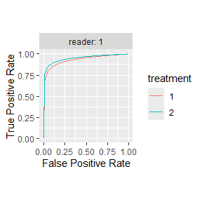

```r
plot(est)
```

**Show SRMC ROC Curve Parameters**

```r
print(parameters(est))
```

```
## # A tibble: 2 × 3
##   Group$reader $treatment     a     b
##   <fct>        <fct>      <dbl> <dbl>
## 1 1            1           1.70 0.537
## 2 1            2           1.85 0.503
```

**Show SRMC Test Results**

```r
summary(est)
```

```
## Single-Reader Multi-Case Analysis of Variance
## Data: VanDyke1
## Factor types: Fixed Readers and Random Cases
## Covariance method: jackknife
##
## Experimental design: cases nested within reader
##
## Obuchowski-Rockette variance component and covariance estimates:
##
##           Estimate Correlation
## Error 0.0008371345          NA
## Cov1  0.0004275594   0.5107416
## Cov2  0.0000000000   0.0000000
## Cov3  0.0000000000   0.0000000
##
##
## 95% CIs and tests for treatment binormal_auc pairwise differences:
##   Comparison    Estimate    StdErr    CI.Lower    CI.Upper         z  p-value
## 1      1 - 2 -0.01765763 0.0286208 -0.07375337  0.03843810 -0.616951 0.537267
##
##
## Single reader 95% CIs:
##   binormal_auc treatment reader     StdErr  CI.Lower  CI.Upper
## 1    0.9331609         1      1 0.03348342 0.8675346 0.9987872
## 2    0.9508186         2      1 0.02351871 0.9047228 0.9969144
```

# 7 Single-Test Multi-Case Analysis

A single-test and single-reader multi-case (STMC) analysis involves a single reader of multiple cases to estimate a reader performance metric for one diagnostic test. An STMC analysis can be performed with a call to `stmc()`.

> **STMC Function**

> `stmc(response, case, data, cov = jackknife)`

> *Description*

> Returns an `stmc` class object of data that can be used to estimate a reader performance metric in a single-test and single-reader multi-case statistical analysis.

> *Arguments*
> - `response`: object defining true case statuses, corresponding reader ratings, and a reader performance metric to compute on them.
> - `case`: variable containing the case identifiers for the `response` observations.
> - `data`: data frame containing the response and identifier variables.
> - `cov`: function `jackknife`, `unbiased`, or `DeLong` to estimate reader performance metric covariances.

The function is used similar to `mrmc()` but without the `test` and `reader` arguments. In the following example, an STMC analysis is performed with one of the tests and readers from the `VanDyke` dataset.

```r
## Subset VanDyke dataset by treatment 1 and reader 1
VanDyke11 <- subset(VanDyke, treatment == "1" & reader == "1")

## Estimate ROC AUC for treatment 1 and reader 1
est <- stmc(binormal_auc(truth, rating), case, data = VanDyke11)
```

**Show STMC ROC Curve**

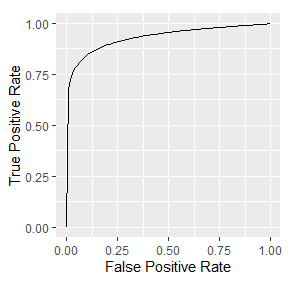

```r
plot(est)
```

**Show STMC ROC Curve Parameters**

```r
print(parameters(est))
```

```
## # A tibble: 1 × 2
##       a     b
##   <dbl> <dbl>
## 1  1.70 0.537
```

**Show STMC ROC AUC Estimate**

```r
summary(est)
```

```
## binormal_auc       StdErr     CI.Lower     CI.Upper
##   0.93316094   0.03348342   0.86753465   0.99878723
```

# 8 ROC Curves

ROC curves can be estimated, summarized, and displayed apart from a multi-case statistical analysis with the `roc_curves()` function. Supported estimation methods include the empirical distribution (default), binormal model, and binormal likelihood-ratio model.

## 8.1 Curve Fitting

> **ROC Curves Function**

> `roc_curves(truth, rating, groups = list(), method = "empirical")`

> *Description*

> Returns an `roc_curves` class object of estimated ROC curves.

> *Arguments*
> - `truth`: vector of true binary case statuses, with positive status taken to be the highest level.
> - `rating`: numeric vector of case ratings.
> - `groups` : list or data frame of grouping variables of the same lengths as `truth` and `rating`.
> - `method`: character string indicating the curve type as `"binormal"`, `"binormalLR"`, `"empirical"`, or `"trapezoidal"`.

A single curve can be estimated over all observations or multiple curves estimated within the levels of one or more grouping variables. Examples of both are given in the following sections using variables from the `VanDyke` dataset referenced inside of calls to the `with()` function. Alternatively, the variables may be referenced with the `$` operator; e.g., `VanDyke$truth` and `VanDyke$rating`. Resulting curves from `roc_curves()` can be displayed with the `print()` and `plot()` functions.

### 8.1.1 Single Curve

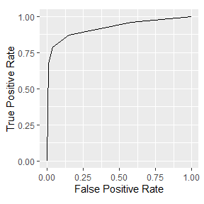

```r
## Direct referencing of data frame columns
# curve <- roc_curves(VanDyke$truth, VanDyke$rating)

## Indirect referencing using the with function
curve <- with(VanDyke, {
  roc_curves(truth, rating)
})
plot(curve)
```

### 8.1.2 Multiple Curves

Multiple group-specific curves can be obtained from `roc_curves()` by supplying a list or data frame of grouping variables to the `groups` argument. Groups will be formed and displayed in the order in which grouping variables are supplied. For instance, a second grouping variable will be plotted within the first one.

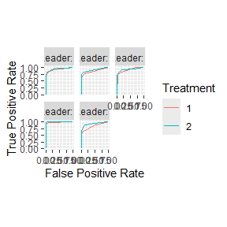

```r
## Grouped by reader
curves <- with(VanDyke, {
  roc_curves(truth, rating,
             groups = list(Reader = reader, Treatment = treatment))
})
plot(curves)
```

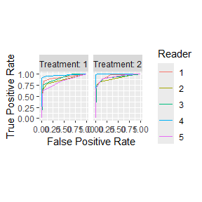

```r
## Grouped by treatment
curves <- with(VanDyke, {
  roc_curves(truth, rating,
             groups = list(Treatment = treatment, Reader = reader))
})
plot(curves)
```

### 8.1.3 Parametric Curves

Estimated parameters for curves obtained with the binormal or binormal likelihood-ratio models can be extracted as a data frame with the `parameters()` function.

```r
## Binormal curves
curves_binorm <- with(VanDyke, {
  roc_curves(truth, rating,
             groups = list(Treatment = treatment, Reader = reader),
             method = "binormal")
})
params_binorm <- parameters(curves_binorm)
print(params_binorm)
```

```
## # A tibble: 10 × 3
##    Group$Treatment $Reader      a     b
##    <fct>           <fct>    <dbl> <dbl>
##  1 1               1         1.70 0.537
##  2 2               1         1.85 0.503
##  3 1               2         1.40 0.561
##  4 2               2         1.66 0.447
##  5 1               3         1.74 0.635
##  6 2               3         1.62 0.488
##  7 1               4         1.93 0.202
##  8 2               4       Inf    1
##  9 1               5         1.06 0.464
## 10 2               5         1.73 0.422
```

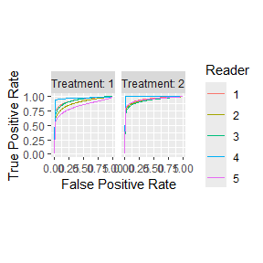

```r
plot(curves_binorm)
```

Estimates for different parameterizations of the binormal likelihood-ratio model are additionally returned and include those of the binormal model and the simplification of Pan and Metz (1997; Metz and Pan 1999) as well as those of the bi-chi-squared model (Hillis 2017).

```r
## Binormal likelihood-ratio curves
curves_binormLR <- with(VanDyke, {
  roc_curves(truth, rating,
             groups = list(Treatment = treatment, Reader = reader),
             method = "binormalLR")
})
params_binormLR <- parameters(curves_binormLR)
print(params_binormLR)
```

```
## # A tibble: 10 × 4
##    Group$Treatment $Reader   Metz$d_a     $c bichisquared$lambda binormal$a
##    <fct>           <fct>        <dbl>  <dbl>               <dbl>      <dbl>
##  1 1               1         2.13     -0.298                3.42   1.71
##  2 2               1         2.35     -0.321                3.79   1.87
##  3 1               2         1.73     -0.281                3.17   1.40
##  4 2               2         0.00700  -0.791               73.3    0.00499
##  5 1               3         0.00606  -0.746               47.0    0.00433
##  6 2               3         2.08     -0.330                3.94   1.65
##  7 1               4         0.000211 -0.932              797.     0.000149
##  8 2               4       Inf         0                    1    Inf
##  9 1               5         0.895    -0.508                9.37   0.666
## 10 2               5         2.02     -0.553               12.1    1.49
## # ℹ 2 more variables: bichisquared$theta <dbl>, binormal$b <dbl>
```

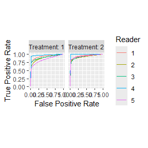

```r
plot(curves_binormLR)
```

## 8.2 Curve Points

Points on an ROC curve estimated with `roc_curves()` can be extracted with the `points()` function. True positive rates (TPRs) and false positive rates (FPRs) on the estimated curve are returned for a given set of sensitivity or specificity values or, in the case of empirical curves, the original points. ROC curve points can be displayed with `print()` and `plot()`.

> **ROC Points Function**

> `## Method for class 'roc_curves'`  
> `points(x, metric = "specificity", values = seq(0, 1, length = 101), ...)`

> `## Method for class 'empirical_curves'`  
> `points(x, metric = "specificity", values = NULL, which = "curve", ...)`

> *Description*

> Returns an `roc_points` class object that is a data frame of false positive and true positive rates from an estimated ROC curve.

> *Arguments*
> - `x`: object from `roc_curves()` for which to compute points on the curves.
> - `metric`: character string specifying `"specificity"` or `"sensitivity"` as the reader performance metric to which `values` correspond.
> - `values`: numeric vector of values at which to compute ROC curve points, or `NULL` for default empirical values as determined by `which`.
> - `which`: character string indicating whether to use curve-specific observed values and 0 and 1 (`"curve"`), the combination of these values over all curves (`"curves"`), or only the observed curve-specific values (`"observed"`).

```r
## Extract points at given specificities
curve_spec_pts <- points(curves, metric = "spec", values = c(0.5, 0.7, 0.9))
print(curve_spec_pts)
```

```
## # A tibble: 30 × 3
##    Group$Treatment $Reader   FPR   TPR
##  * <fct>           <fct>   <dbl> <dbl>
##  1 1               1         0.1 0.862
##  2 1               1         0.3 0.908
##  3 1               1         0.5 0.935
##  4 2               1         0.1 0.843
##  5 2               1         0.3 0.966
##  6 2               1         0.5 0.978
##  7 1               2         0.1 0.747
##  8 1               2         0.3 0.821
##  9 1               2         0.5 0.872
## 10 2               2         0.1 0.821
## # ℹ 20 more rows
```

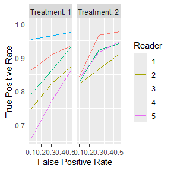

```r
plot(curve_spec_pts, coord_fixed = FALSE)
```

```r
## Extract points at given sensitivities
curve_sens_pts <- points(curves, metric = "sens", values = c(0.5, 0.7, 0.9))
print(curve_sens_pts)
```

```
## # A tibble: 30 × 3
##    Group$Treatment $Reader    FPR   TPR
##  * <fct>           <fct>    <dbl> <dbl>
##  1 1               1       0.0116   0.5
##  2 1               1       0.0246   0.7
##  3 1               1       0.254    0.9
##  4 2               1       0        0.5
##  5 2               1       0        0.7
##  6 2               1       0.337    0.9
##  7 1               2       0.0130   0.5
##  8 1               2       0.0543   0.7
##  9 1               2       0.609    0.9
## 10 2               2       0        0.5
## # ℹ 20 more rows
```

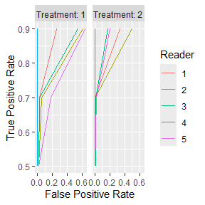

```r
plot(curve_sens_pts, coord_fixed = FALSE)
```

## 8.3 Mean Curves

A mean ROC curve from multiple group-specific curves returned by `roc_curves()` can be computed with the `means()` function. Curves can be averaged over sensitivities, specificities, or binormal parameters (Chen and Samuelson 2014). Averaged curves can be displayed with `print()` and `plot()`.

> **ROC Means Function**

> `## Method for class 'roc_curves'`  
> `mean(x, ...)`

> `## Method for class 'binormal_curves'`  
> `mean(x, method = "points", ...)`

> *Description*

> Returns an `roc_points` class object.

> *Arguments*
> - `x`: object from `roc_curves()` for which to average over the curves.
> - `method`: character string indicating whether to average binormal curves over `"points"` or `"parameters"`.
> - `...`: optional arguments passed to `points()`, including at which `metric` (`"sensitivity"` or `"specificity"`) values to average points on the ROC curves.

```r
## Average sensitivities at given specificities (default)
curves_mean <- mean(curves)
print(curves_mean)
```

```
## # A tibble: 20 × 2
##       FPR   TPR
##  *  <dbl> <dbl>
##  1 0      0
##  2 0      0.402
##  3 0.0145 0.686
##  4 0.0290 0.762
##  5 0.0435 0.790
##  6 0.0580 0.802
##  7 0.0725 0.813
##  8 0.101  0.835
##  9 0.116  0.844
## 10 0.130  0.852
## 11 0.159  0.862
## 12 0.188  0.872
## 13 0.319  0.904
## 14 0.362  0.912
## 15 0.435  0.925
## 16 0.638  0.956
## 17 0.667  0.961
## 18 0.696  0.966
## 19 0.913  0.992
## 20 1      1
```

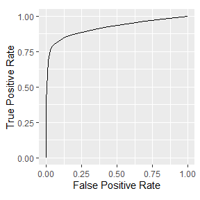

```r
plot(curves_mean)
```

```r
## Average specificities at given sensitivities
curves_mean <- mean(curves, metric = "sens")
print(curves_mean)
```

```
## # A tibble: 23 × 2
##        FPR   TPR
##  *   <dbl> <dbl>
##  1 0       0
##  2 0.00698 0.511
##  3 0.00804 0.556
##  4 0.00899 0.578
##  5 0.00995 0.6
##  6 0.0109  0.622
##  7 0.0214  0.667
##  8 0.0280  0.689
##  9 0.0358  0.711
## 10 0.0450  0.733
## # ℹ 13 more rows
```

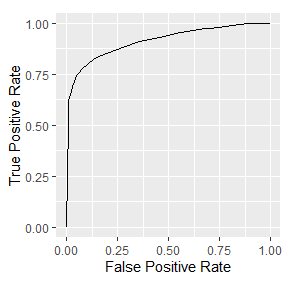

```r
plot(curves_mean)
```

# 9 Reader Performance Metrics

The reader performance metrics described previously for use with `mrmc()` and related functions to analyze multi and single-reader multi-case studies can be applied to truth and rating vectors as stand-alone functions. This enables estimation of performance metrics for other applications, such as predictive modeling, that may be of interest.

## 9.1 ROC Curve Metrics

AUC, partial AUC, sensitivity, and specificity are estimated below with an empirical ROC curve. Estimates with binormal and binormal likelihood-ratio curves can be obtained by replacing `empirical` in the function names with `binormal` and `binormalLR`, respectively.

```r
## Total area under the empirical ROC curve
empirical_auc(VanDyke$truth, VanDyke$rating)
```

```
## [1] 0.9229791
```

```r
## Partial area for specificity from 0.7 to 1.0
empirical_auc(VanDyke$truth, VanDyke$rating, partial = "spec", min = 0.70, max = 1.0)
```

```
## [1] 0.2499923
```

```r
## Partial area for sensitivity from 0.7 to 1.0
empirical_auc(VanDyke$truth, VanDyke$rating, partial = "sens", min = 0.70, max = 1.0)
```

```
## [1] 0.2262129
```

```r
## Sensitivity for given specificity
empirical_sens(VanDyke$truth, VanDyke$rating, spec = 0.8)
```

```
## [1] 0.8812346
```

```r
## Sensitivity for given specificity
empirical_spec(VanDyke$truth, VanDyke$rating, sens = 0.8)
```

```
## [1] 0.94434
```

## 9.2 Binary Metrics

Sensitivity and specificity for binary ratings are available with the `binary_sens()` and `binary_spec()` functions as demonstrated in the next example based on a binary rating created from the numeric one in the `VanDyke` dataset.

```r
## Create binary classification
VanDyke$binary_rating <- VanDyke$rating >= 3

## Sensitivity
binary_sens(VanDyke$truth, VanDyke$binary_rating)
```

```
## [1] 0.8711111
```

```r
## Specificity
binary_spec(VanDyke$truth, VanDyke$binary_rating)
```

```
## [1] 0.8478261
```

# References

Abbey, Craig K, Frank W Samuelson, and Brandon D Gallas. 2013. “Statistical Power Considerations for a Utility Endpoint in Observer Performance Studies.” *Academic Radiology* 207: 798–806.

Chen, W, and Frank W Samuelson. 2014. “The Average Receiver Operating Characteristic Curve in Multireader Multicase Imaging Studies.” *The British Journal of Radiology* 87: 20140016.

DeLong, E R, D M DeLong, and D L Clarke-Pearson. 1988. “Comparing the Areas Under Two or More Correlated Receiver Operating Characteristic Curves: A Nonparametric Approach.” *Biometrics* 44: 837–45.

Dorfman, D D, K S Berbaum, and C E Metz. 1992. “Receiver Operating Characteristic Rating Analysis. Generalization to the Population of Readers and Patients with the Jackknife Method.” *Investigative Radiology* 27: 723–31.

Efron, Bradley. 1982. *The Jackknife, the Bootstrap and Other Resampling Plans*. Philadelphia: SIAM.

Gallas, B D, G A Pennello, and K J Meyers. 2007. “Multireader Multicase Variance Analysis for Binary Data.” *Journal of the Optical Society of America A* 24: B70–80.

Hillis, S L. 2007. “A Comparison of Denominator Degrees of Freedom Methods for Multiple Observer ROC Analysis.” *Statistics in Medicine* 26: 596–619.

———. 2014. “A Marginal-Mean ANOVA Approach for Analyzing Mulitreader Multicase Radiological Imaging Data.” *Statistics in Medicine* 33: 330–60.

———. 2017. “Equivalence of Binormal Likelihood-Ratio and Bi-Chi-Squared ROC Curve Models.” *Statistics in Medicine* 35: 2031–57.

———. 2018. “Relationship Between Roe and Metz Simulation Model for Multireader Diagnostic Data and Obuchowski-Rockette Model Parameters.” *Statistics in Medicine* 37: 2067–93.

Hillis, S L, K S Berbaum, and C E Metz. 2008. “Recent Developments in the Dorfman-Berbaum-Metz Procedure for Multireader ROC Study Analysis.” *Academic Radiology* 15: 647–61.

Hillis, S L, N A Obuchowski, K M Schartz, and K S Berbaum. 2005. “A Comparison of the Dorfman-Berbaum-Metz and Obuchowski-Rockette Methods for Receiver Operating Characteristic (ROC) Data.” *Statistics in Medicine* 24: 1579–1607.

Metz, Charles E, and Xiaochuan Pan. 1999. “"Proper" Binormal ROC Curves: Theory and Maximum-Likelihood Estimation.” *Journal of Mathematical Psychology* 43: 1–33.

Obuchowski, N A, and H E Rockette. 1995. “Hypothesis Testing of Diagnostic Accuracy for Multiple Readers and Multiple Tests: An ANOVA Approach with Dependent Observations.” *Communications in Statistics–Simulation and Computation* 24: 285–308.

Pan, Xiaochuan, and Charles E Metz. 1997. “The "Proper" Binormal Model: Parametric Receiver Operating Characteristic Curve Estimation with Degenerate Data.” *Statistics in Radiology* 4: 380–89.

Smith, Brian J, Stephen L Hillis, and Lorenzo L Pesce. 2022. *MCMCaov: Multi-Reader Multi-Case Analysis of Variance*. https://github.com/brian-j-smith/MRMCaov.

VanDyke, C W, R D White, N A Obuchowski, M A Geisinger, R J Lorig, and M A Meziane. 1993. “Cine MRI in the Diagnosis of Thoracic Aortic Dissection.” Chicago, IL.